# Predictive Machine Learning Project

Fabio Amaral

19 February 2015

# Introduction

Using devices such as Jawbone Up, Nike FuelBand, and Fitbit it is now possible to collect a large amount of data about personal activity relatively inexpensively. These type of devices are part of the quantified self movement – a group of enthusiasts who take measurements about themselves regularly to improve their health, to find patterns in their behavior, or because they are tech geeks. One thing that people regularly do is quantify how much of a particular activity they do, but they rarely quantify how well they do it. In this project, we used data from accelerometers on the belt, forearm, arm, and dumbell of 6 participants. They were asked to perform barbell lifts correctly and incorrectly in 5 different ways:

1. Exactly according to the specification
2. Throwing elbows to the front
3. Lifting the dumbbell only halfway
4. lowering the dumbbell only halfway
5. throwing the hips to the front

More information is available from the website here: http://groupware.les.inf.puc-rio.br/har (see the section on the Weight Lifting Exercise Dataset).

## Objectives

The goal of the project was to predict the manner in which the subjects did the exercise. This is the “classe” variable in the training set. Any of the other variables could be used to predict with. A report shoud be created describing how our model was built, how cross validation was used, what the expected out of sample error was, and why we made the model choices. We will also used our prediction model to predict 20 different test cases.

# Prepare data set

The training data for this project are available here:

https://d396qusza40orc.cloudfront.net/predmachlearn/pml-training.csv

The test data are available here:

https://d396qusza40orc.cloudfront.net/predmachlearn/pml-testing.csv

## Download and load data set

The original training dataset contains 153 variables and 19622 boservations and the clean test set 153 variables and 20 observations.

```r
# Download data
trainUrl <-"https://d396qusza40orc.cloudfront.net/predmachlearn/pml-training.csv"
testUrl <- "https://d396qusza40orc.cloudfront.net/predmachlearn/pml-testing.csv"

trainFile <- "./data/pml-training.csv"
testFile  <- "./data/pml-testing.csv"

if (!file.exists("./data")) {
        dir.create("./data")
}

if (!file.exists(trainFile)) {
        download.file(trainUrl, destfile=trainFile, method="curl")
}

if (!file.exists(testFile)) {
        download.file(testUrl, destfile=testFile, method="curl")
}

# Load data and replace invalid strings and absent values for "NA"
trainRaw <- read.csv("./data/pml-training.csv", na.strings=c("NA","NaN","#DIV/0!", ""))
testRaw <- read.csv("./data/pml-testing.csv", na.strings=c("NA","NaN","#DIV/0!", ""))
```

## Clean data set

After removing variables containing near zero variance, were missing values for over 60% of the observations were simply irrelevant for the assignment, the clean training dataset was left with 53 variables and 19622 observations and the clean test set 53 variables and 20 observations.

```r
# Identify and remove irelevant variable for prediction
#names(trainRaw)
# Columns 1 to 7 will be removed
removeVars <- grepl("^X|user|timestamp|window", names(trainRaw))
trainRaw <- trainRaw[, !removeVars]

# Removing zero covariates - Identify and remove predictors with near zero variance
suppressPackageStartupMessages(require(caret))
nzv <- nearZeroVar(trainRaw, saveMetrics=TRUE)
nzv <- nearZeroVar(trainRaw)
filteredTrain <- trainRaw[, -nzv]

# Identify and remove predictors with 60% or more missing values
cleanTrain <- filteredTrain[, colSums(is.na(filteredTrain)) <= 0.6*nrow(filteredTrain)]

# Repeat above process with test set

# Columns 1 to 7 will be removed
testRaw <- testRaw[, !removeVars]

# Identify and remove predictors which were removed from training data
filteredTest <- testRaw[, -nzv]

# Identify and remove predictors with 60% or more missing values like done for training data
cleanTest <- filteredTest[, colSums(is.na(filteredTest)) <= 0.6*nrow(filteredTest)]
```

## Data Slicing

The clean training data set was split in two parts, 60% for training and 40% for testing.

```r
set.seed(12345)
inTrain <- createDataPartition(cleanTrain$classe, p=0.60, list=F)
training <- cleanTrain[inTrain,] #60%
testing <- cleanTrain[-inTrain,] #40%
```

# Exploratory Analysis of Predictor Correlation

## Verification for Correlation of Predictors

Firstly we perform an exploratory data analysis to assess for the correlation of predictors.

```r
M <- abs(cor(training[,-53]))
diag(M) <- 0
which(M > 0.8, arr.ind=T) #which variables have greater correlation than 0.8
```

```
##                  row col
## yaw_belt           3   1
## total_accel_belt   4   1
## accel_belt_y       9   1
## accel_belt_z      10   1
## accel_belt_x       8   2
## magnet_belt_x     11   2
## roll_belt          1   3
## roll_belt          1   4
## accel_belt_y       9   4
## accel_belt_z      10   4
## pitch_belt         2   8
## magnet_belt_x     11   8
## roll_belt          1   9
## total_accel_belt   4   9
## accel_belt_z      10   9
## roll_belt          1  10
## total_accel_belt   4  10
## accel_belt_y       9  10
## pitch_belt         2  11
## accel_belt_x       8  11
## gyros_arm_y       19  18
## gyros_arm_x       18  19
## magnet_arm_x      24  21
## accel_arm_x       21  24
## magnet_arm_z      26  25
## magnet_arm_y      25  26
## accel_dumbbell_x  34  28
## accel_dumbbell_z  36  29
## gyros_dumbbell_z  33  31
## gyros_forearm_z   46  31
## gyros_dumbbell_x  31  33
## gyros_forearm_z   46  33
## pitch_dumbbell    28  34
## yaw_dumbbell      29  36
## gyros_forearm_z   46  45
## gyros_dumbbell_x  31  46
## gyros_dumbbell_z  33  46
## gyros_forearm_y   45  46
```

### Correlation Matrix

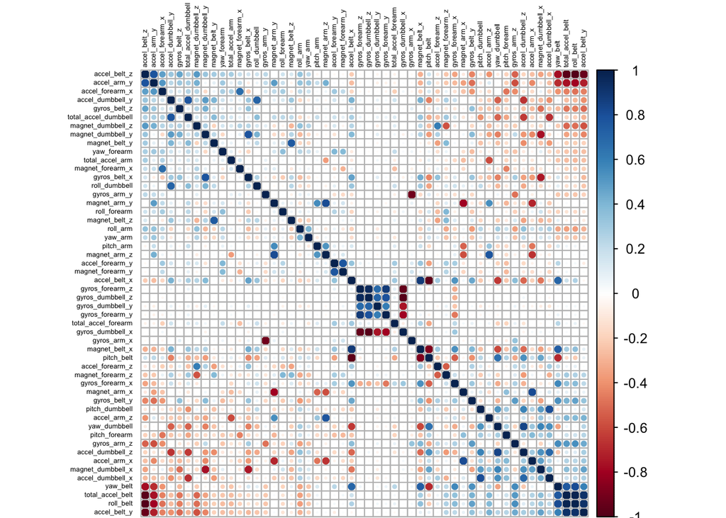

```r
suppressPackageStartupMessages(require(corrplot))
corMatrix <- cor(training[, -53]) #Col 53 is the outcome label
corrplot(corMatrix, order = "FPC", method="circle", tl.cex = 0.4,  tl.col = rgb(0, 0, 0))
```

# Predictive Modeling

We tested several modelling algoriths with varied accuracy outcomes and processing times(**See appendix**).

## Random forest

The **Random Forest** method was chosen since it showed the **highest accuracy rate** and because of its robustness to correlated covariates and presence of outliers. We chose to use **10 fold cross validation** when applying the algorithm.

### Train by Random Forrest

```r
set.seed(12345)
controlCV <- trainControl(method="cv")
system.time(rf.Model <- train(classe ~., data=training, method="rf", trControl=controlCV))
```

```
##     user   system  elapsed
## 1413.897   27.990 1464.216
```

### Random Forrest Modelling Parameters

```r
rf.Model
```

```
## Random Forest
##
## 11776 samples
##    52 predictor
##     5 classes: 'A', 'B', 'C', 'D', 'E'
##
## No pre-processing
## Resampling: Cross-Validated (10 fold)
##
## Summary of sample sizes: 10598, 10599, 10600, 10599, 10598, 10599, ...
##
## Resampling results across tuning parameters:
##
##   mtry  Accuracy   Kappa      Accuracy SD  Kappa SD
##    2    0.9902357  0.9876478  0.003536607  0.004473952
##   27    0.9898109  0.9871101  0.003369428  0.004263986
##   52    0.9868380  0.9833486  0.003906206  0.004943972
##
## Accuracy was used to select the optimal model using  the largest value.
## The final value used for the model was mtry = 2.
```

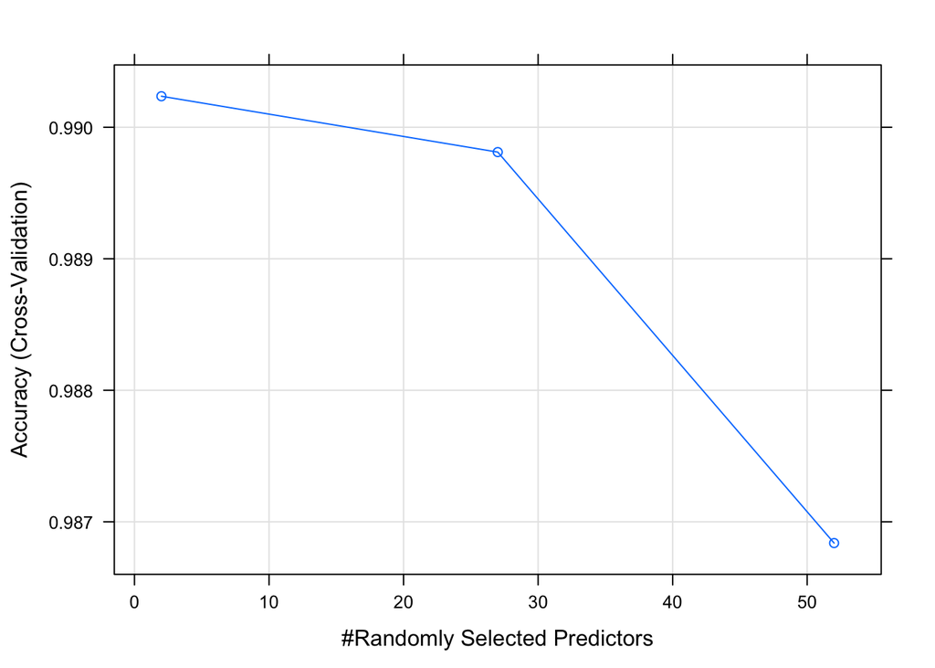

```r
plot(rf.Model)
```

### Random Forrest Final Model

```r
rf.Model$finalModel
```

```
##
## Call:
##  randomForest(x = x, y = y, mtry = param$mtry)
##                Type of random forest: classification
##                      Number of trees: 500
## No. of variables tried at each split: 2
##
##         OOB estimate of  error rate: 0.93%
## Confusion matrix:
##      A    B    C    D    E class.error
## A 3342    3    2    0    1 0.001792115
## B   17 2252   10    0    0 0.011847301
## C    1   14 2035    4    0 0.009250243
## D    0    0   45 1881    4 0.025388601
## E    0    0    1    8 2156 0.004157044
```

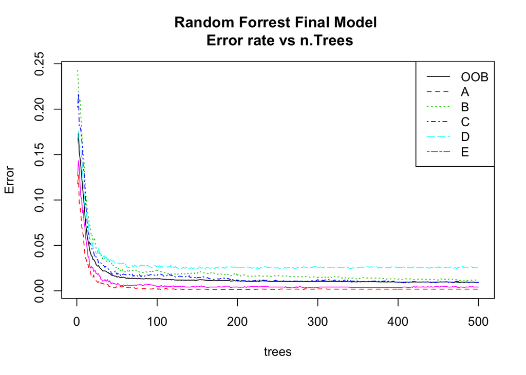

```r
plot(rf.Model$finalModel, main="Random Forrest Final Model \n Error rate vs n.Trees")
legend("topright", legend = c("OOB", "A", "B", "C", "D", "E"), lty=(1:6), col = c(1:6))
```

The expected **level of accuracy** was above 98% and the **Out Of Bag Error Rate** was 0.93% as seen in the results and plots above determined by **Crossvalidation**. These results might be overestimated, so we performed validation to have better confidence in our results.

### Evaluate Random Forest Model

The performance of the predictive model is then tested on the validation datset

```r
rf.predictions <- predict(rf.Model, testing)
```

### Confusion Matrix - Random Forrest

```r
confusionMatrix(rf.predictions, testing$classe)
```

```
## Confusion Matrix and Statistics
##
##           Reference
## Prediction    A    B    C    D    E
##          A 2228    9    0    0    0
##          B    4 1504    8    0    0
##          C    0    5 1359   22    2
##          D    0    0    1 1263    3
##          E    0    0    0    1 1437
##
## Overall Statistics
##
##                Accuracy : 0.993
##                  95% CI : (0.9909, 0.9947)
##     No Information Rate : 0.2845
##     P-Value [Acc > NIR] : < 2.2e-16
##
##                   Kappa : 0.9911
##  Mcnemar's Test P-Value : NA
##
## Statistics by Class:
##
##                      Class: A Class: B Class: C Class: D Class: E
## Sensitivity            0.9982   0.9908   0.9934   0.9821   0.9965
## Specificity            0.9984   0.9981   0.9955   0.9994   0.9998
## Pos Pred Value         0.9960   0.9921   0.9791   0.9968   0.9993
## Neg Pred Value         0.9993   0.9978   0.9986   0.9965   0.9992
## Prevalence             0.2845   0.1935   0.1744   0.1639   0.1838
## Detection Rate         0.2840   0.1917   0.1732   0.1610   0.1832
## Detection Prevalence   0.2851   0.1932   0.1769   0.1615   0.1833
## Balanced Accuracy      0.9983   0.9944   0.9945   0.9908   0.9982
```

```r
oose <- 1 - as.numeric(confusionMatrix(rf.predictions, testing$classe)$overall[1])
oose
```

```
## [1] 0.007009941
```

# Prediction on Test Set

Finally the Random Forest trained model was applied on the testing data to make the 20 assigned predictions.

```r
predict(rf.Model, cleanTest)
```

```
##  [1] B A B A A E D B A A B C B A E E A B B B
## Levels: A B C D E
```

# Appendix - Modelling Algorithms Tested

## Classification tree

rpart - non-linear, use interactions between variables, data transformations are not so important

### Train by Classification Tree

```r
suppressPackageStartupMessages(require(rpart))
set.seed(12345)
system.time(dt.Model <- train(classe ~ ., data=training, method="rpart"))
```

```
##    user  system elapsed
##  44.373   1.092  45.760
```

### Classification Tree Modeling Parameters

```r
dt.Model
```

```
## CART
##
## 11776 samples
##    52 predictor
##     5 classes: 'A', 'B', 'C', 'D', 'E'
##
## No pre-processing
## Resampling: Bootstrapped (25 reps)
##
## Summary of sample sizes: 11776, 11776, 11776, 11776, 11776, 11776, ...
##
## Resampling results across tuning parameters:
##
##   cp          Accuracy   Kappa       Accuracy SD  Kappa SD
##   0.03909587  0.5013960  0.35074858  0.06575246   0.11060004
##   0.03946369  0.4988374  0.34682528  0.06482813   0.10893077
##   0.11449929  0.3333384  0.07372353  0.03986768   0.06147208
##
## Accuracy was used to select the optimal model using  the largest value.
## The final value used for the model was cp = 0.03909587.
```

### Classification Tree Final Model

```r
dt.Model$finalModel
```

```
## n= 11776
##
## node), split, n, loss, yval, (yprob)
##       * denotes terminal node
##
##  1) root 11776 8428 A (0.28 0.19 0.17 0.16 0.18)
##    2) roll_belt< 130.5 10799 7457 A (0.31 0.21 0.19 0.18 0.11)
##      4) pitch_forearm< -33.95 945    8 A (0.99 0.0085 0 0 0) *
##      5) pitch_forearm>=-33.95 9854 7449 A (0.24 0.23 0.21 0.2 0.12)
##       10) yaw_belt>=169.5 495   47 A (0.91 0.038 0 0.051 0.0061) *
##       11) yaw_belt< 169.5 9359 7107 B (0.21 0.24 0.22 0.2 0.13)
##         22) magnet_dumbbell_z< -93.5 1118  467 A (0.58 0.29 0.046 0.055 0.029) *
##         23) magnet_dumbbell_z>=-93.5 8241 6238 C (0.16 0.23 0.24 0.22 0.14)
##           46) pitch_belt< -42.95 500   79 B (0.018 0.84 0.094 0.026 0.02) *
##           47) pitch_belt>=-42.95 7741 5785 C (0.17 0.19 0.25 0.24 0.15)
##             94) accel_forearm_x>=-99.5 4688 3417 C (0.21 0.22 0.27 0.12 0.18) *
##             95) accel_forearm_x< -99.5 3053 1776 D (0.096 0.16 0.22 0.42 0.1) *
##    3) roll_belt>=130.5 977    6 E (0.0061 0 0 0 0.99) *
```

### Evaluate Classification Tree Model

```r
dt.predictions <- predict(dt.Model, testing)
```

### Confusion Matrix - Classification Tree

```r
confusionMatrix(dt.predictions, testing$classe)
```

```
## Confusion Matrix and Statistics
##
##           Reference
## Prediction    A    B    C    D    E
##          A 1357  229   38   66   15
##          B    3  259   28    8   10
##          C  693  725  819  389  557
##          D  171  305  483  823  200
##          E    8    0    0    0  660
##
## Overall Statistics
##
##                Accuracy : 0.4994
##                  95% CI : (0.4882, 0.5105)
##     No Information Rate : 0.2845
##     P-Value [Acc > NIR] : < 2.2e-16
##
##                   Kappa : 0.3764
##  Mcnemar's Test P-Value : < 2.2e-16
##
## Statistics by Class:
##
##                      Class: A Class: B Class: C Class: D Class: E
## Sensitivity            0.6080  0.17062   0.5987   0.6400  0.45770
## Specificity            0.9380  0.99226   0.6351   0.8233  0.99875
## Pos Pred Value         0.7959  0.84091   0.2573   0.4152  0.98802
## Neg Pred Value         0.8575  0.83298   0.8823   0.9210  0.89106
## Prevalence             0.2845  0.19347   0.1744   0.1639  0.18379
## Detection Rate         0.1730  0.03301   0.1044   0.1049  0.08412
## Detection Prevalence   0.2173  0.03926   0.4057   0.2526  0.08514
## Balanced Accuracy      0.7730  0.58144   0.6169   0.7316  0.72822
```

### Plot the Classification Decision Tree

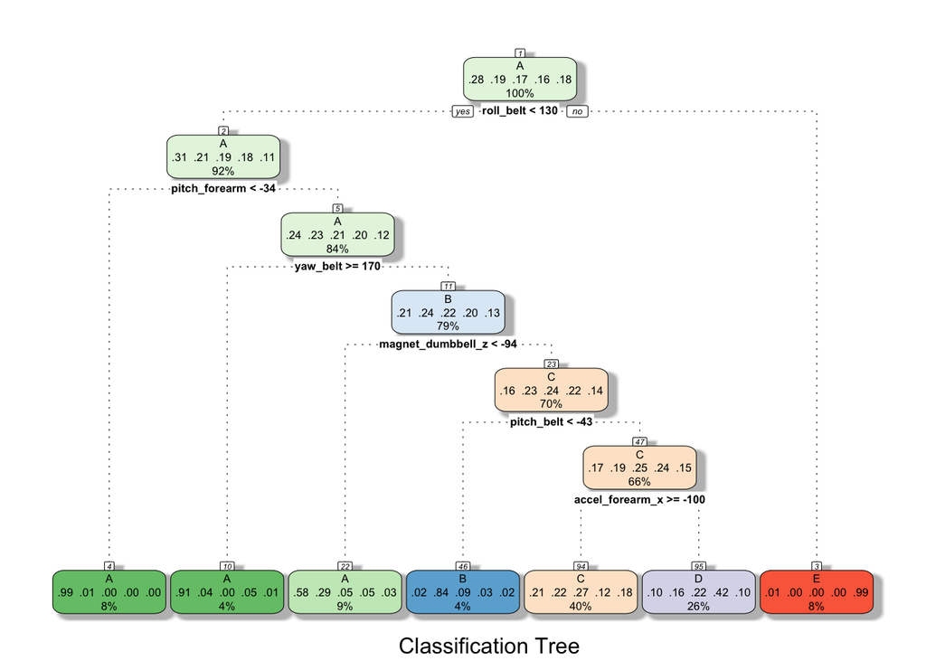

```r
rattle::fancyRpartPlot(dt.Model$finalModel, sub = "Classification Tree")
```

## Linear Discriminant Analysis

Is a multivariate Gaussian with same covariances

### Train by Linear Discriminant Analysis

```r
system.time(lda.Model <- train(training$classe ~., data=training, method="lda"))
```

```
##    user  system elapsed
##   9.445   0.779  10.340
```

### Linear Discriminant Analysis Modelling Parameters

```r
lda.Model
```

```
## Linear Discriminant Analysis
##
## 11776 samples
##    52 predictor
##     5 classes: 'A', 'B', 'C', 'D', 'E'
##
## No pre-processing
## Resampling: Bootstrapped (25 reps)
##
## Summary of sample sizes: 11776, 11776, 11776, 11776, 11776, 11776, ...
##
## Resampling results
##
##   Accuracy   Kappa     Accuracy SD  Kappa SD
##   0.7000035  0.620121  0.006604469  0.008266298
##
##
```

### Random Linear Discriminant Analysis Model

```r
lda.Model$finalModel
```

[output not shown]

[output cut: 137 more lines]

[output not shown]

### Evaluate Linear Discriminant Analysis Model

```r
lda.predictions <- predict(lda.Model, testing)
```

### Confusion Matrix - Linear Discriminant Analysis

```r
confusionMatrix(lda.predictions, testing$classe)
```

```
## Confusion Matrix and Statistics
##
##           Reference
## Prediction    A    B    C    D    E
##          A 1856  240  165   82   58
##          B   40  963  130   58  249
##          C  173  190  895  160  118
##          D  155   49  147  930  138
##          E    8   76   31   56  879
##
## Overall Statistics
##
##                Accuracy : 0.7039
##                  95% CI : (0.6937, 0.714)
##     No Information Rate : 0.2845
##     P-Value [Acc > NIR] : < 2.2e-16
##
##                   Kappa : 0.6248
##  Mcnemar's Test P-Value : < 2.2e-16
##
## Statistics by Class:
##
##                      Class: A Class: B Class: C Class: D Class: E
## Sensitivity            0.8315   0.6344   0.6542   0.7232   0.6096
## Specificity            0.9029   0.9246   0.9010   0.9255   0.9733
## Pos Pred Value         0.7730   0.6687   0.5827   0.6554   0.8371
## Neg Pred Value         0.9309   0.9134   0.9250   0.9446   0.9172
## Prevalence             0.2845   0.1935   0.1744   0.1639   0.1838
## Detection Rate         0.2366   0.1227   0.1141   0.1185   0.1120
## Detection Prevalence   0.3060   0.1835   0.1958   0.1809   0.1338
## Balanced Accuracy      0.8672   0.7795   0.7776   0.8243   0.7914
```

## Boosting (Stochastic Gradient Bosting)

High accuracy, similar to random forrest Use gbm (boosting with trees), gamBoost (boosting generalized additive models)

### Train by Boosting

```r
suppressPackageStartupMessages(require(gbm))
suppressPackageStartupMessages(require(survival))
suppressPackageStartupMessages(require(splines))
suppressPackageStartupMessages(require(parallel))
system.time(gbm.Model <- train(classe ~., data=training, method="gbm", verbose=F))
```

```
##     user   system  elapsed
## 1348.818   17.263 1374.275
```

### Boosting Modeling Parameters

```r
gbm.Model
```

```
## Stochastic Gradient Boosting
##
## 11776 samples
##    52 predictor
##     5 classes: 'A', 'B', 'C', 'D', 'E'
##
## No pre-processing
## Resampling: Bootstrapped (25 reps)
##
## Summary of sample sizes: 11776, 11776, 11776, 11776, 11776, 11776, ...
##
## Resampling results across tuning parameters:
##
##   interaction.depth  n.trees  Accuracy   Kappa      Accuracy SD
##   1                   50      0.7484112  0.6813133  0.009316503
##   1                  100      0.8154602  0.7665453  0.007928851
##   1                  150      0.8497926  0.8099697  0.008028870
##   2                   50      0.8497777  0.8097258  0.009050761
##   2                  100      0.9024238  0.8765626  0.005480977
##   2                  150      0.9255169  0.9057969  0.004154616
##   3                   50      0.8912832  0.8624066  0.005749314
##   3                  100      0.9354381  0.9183401  0.003879946
##   3                  150      0.9546230  0.9426218  0.002418775
##   Kappa SD
##   0.011617573
##   0.009907564
##   0.010083699
##   0.011391150
##   0.006905250
##   0.005218393
##   0.007183602
##   0.004889824
##   0.003066563
##
## Tuning parameter 'shrinkage' was held constant at a value of 0.1
## Accuracy was used to select the optimal model using  the largest value.
## The final values used for the model were n.trees = 150,
##  interaction.depth = 3 and shrinkage = 0.1.
```

### Boosting Final Model

```r
gbm.Model$finalModel
```

```
## A gradient boosted model with multinomial loss function.
## 150 iterations were performed.
## There were 52 predictors of which 42 had non-zero influence.
```

### Evaluate Boosting Model

```r
gbm.predictions <- predict(gbm.Model, testing)
```

### Confusion Matrix - Boosting

```r
confusionMatrix(gbm.predictions, testing$classe)
```

```
## Confusion Matrix and Statistics
##
##           Reference
## Prediction    A    B    C    D    E
##          A 2200   43    0    3    1
##          B   20 1430   37    2   16
##          C    8   41 1312   45   15
##          D    3    1   18 1222   20
##          E    1    3    1   14 1390
##
## Overall Statistics
##
##                Accuracy : 0.9628
##                  95% CI : (0.9584, 0.9669)
##     No Information Rate : 0.2845
##     P-Value [Acc > NIR] : < 2.2e-16
##
##                   Kappa : 0.9529
##  Mcnemar's Test P-Value : 1.975e-07
##
## Statistics by Class:
##
##                      Class: A Class: B Class: C Class: D Class: E
## Sensitivity            0.9857   0.9420   0.9591   0.9502   0.9639
## Specificity            0.9916   0.9881   0.9832   0.9936   0.9970
## Pos Pred Value         0.9791   0.9502   0.9233   0.9668   0.9865
## Neg Pred Value         0.9943   0.9861   0.9913   0.9903   0.9919
## Prevalence             0.2845   0.1935   0.1744   0.1639   0.1838
## Detection Rate         0.2804   0.1823   0.1672   0.1557   0.1772
## Detection Prevalence   0.2864   0.1918   0.1811   0.1611   0.1796
## Balanced Accuracy      0.9886   0.9651   0.9711   0.9719   0.9805
```

## Bagging (Bootstrap aggregating)

### Train by Bagging

```r
suppressPackageStartupMessages(require(ipred))
suppressPackageStartupMessages(require(plyr))
system.time(bg.Model <- train(classe ~., data=training, method="treebag", trControl=controlCV))
```

```
##    user  system elapsed
## 447.953   9.322 463.530
```

### Bagging Modeling Parameters

```r
bg.Model
```

```
## Bagged CART
##
## 11776 samples
##    52 predictor
##     5 classes: 'A', 'B', 'C', 'D', 'E'
##
## No pre-processing
## Resampling: Cross-Validated (10 fold)
##
## Summary of sample sizes: 10598, 10598, 10599, 10600, 10599, 10598, ...
##
## Resampling results
##
##   Accuracy   Kappa      Accuracy SD  Kappa SD
##   0.9842048  0.9800195  0.002444864  0.003091163
##
##
```

### Bagging Final Model

```r
bg.Model$finalModel
```

```
##
## Bagging classification trees with 25 bootstrap replications
```

### Evaluate Bagging Model

```r
bag.predictions <- predict(bg.Model, testing)
```

### Confusion Matrix - Bagging

```r
confusionMatrix(bag.predictions, testing$classe)
```

```
## Confusion Matrix and Statistics
##
##           Reference
## Prediction    A    B    C    D    E
##          A 2224   11    0    0    0
##          B    7 1493    7    1    4
##          C    1   11 1353   23    5
##          D    0    2    8 1260    5
##          E    0    1    0    2 1428
##
## Overall Statistics
##
##                Accuracy : 0.9888
##                  95% CI : (0.9862, 0.991)
##     No Information Rate : 0.2845
##     P-Value [Acc > NIR] : < 2.2e-16
##
##                   Kappa : 0.9858
##  Mcnemar's Test P-Value : NA
##
## Statistics by Class:
##
##                      Class: A Class: B Class: C Class: D Class: E
## Sensitivity            0.9964   0.9835   0.9890   0.9798   0.9903
## Specificity            0.9980   0.9970   0.9938   0.9977   0.9995
## Pos Pred Value         0.9951   0.9874   0.9713   0.9882   0.9979
## Neg Pred Value         0.9986   0.9961   0.9977   0.9960   0.9978
## Prevalence             0.2845   0.1935   0.1744   0.1639   0.1838
## Detection Rate         0.2835   0.1903   0.1724   0.1606   0.1820
## Detection Prevalence   0.2849   0.1927   0.1775   0.1625   0.1824
## Balanced Accuracy      0.9972   0.9903   0.9914   0.9887   0.9949
```

# Submission to Coursera

The code below rights the files for submission of the prediction assignment.

```r
rf.predictions <- as.character(predict(rf.Model, cleanTest))

answers = rf.predictions

pml_write_files = function(x){
        n = length(x)
        for(i in 1:n){
                filename = paste0("problem_id_",i,".txt")
                write.table(x[i],file=filename,quote=FALSE,row.names=FALSE,col.names=FALSE)
        }
}

#getwd()
setwd("/Users/pgstudent/Documents/Online_Courses/Data_Science/8-Predictive_Machine_Learning/Project/data")
pml_write_files(answers)
```

# Analysis Environment